# 数据分析课程 01

# https://www.bilibili.com/video/av35553678?p=6

1.使用jupyter notebook进行数据分析  
2.jupyter matplotlib&numpy&pandas 库的入门&使用  
3.Other 学习&复习&提高

## 为什么要学习数据分析

### 数据分析

1.从一堆数据中找到规律  
2.找到规律并应用  
3.图表化的展示&输出  
summary 从数据中找到规律供用户使用

### 为什么学习数据分析

1.岗位需求  
2.python数据科学的基础  
3.机器学习课程的基础

前段js可以做到数据展示  
后端数据库用于数据源的存储  
数据分析用于二者的链接

模块用于高效的分析数据

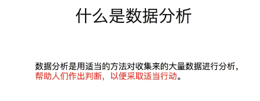

### 数据分析的流程

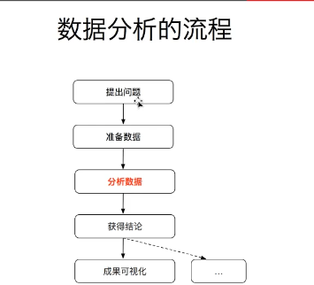

1.数据分析问题一般不怎么清晰  
分析问题  
2.准备数据  
读取数据  
数据清洗  
筛选和排除无效数据  
3.分析数据

4.获得结论  
→直接返回报告

5.结果可视化  
图形图表可视化

2020年1月14日Unknow Timekey

样例1

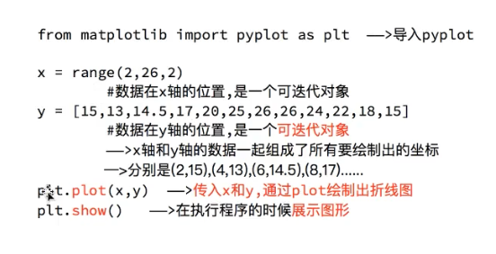

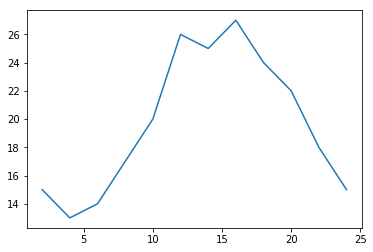

```python
from matplotlib import pyplot as plt
x = range(2,26,2)

y = [15,13,14,17,20,26,25,27,24,22,18,15]
plt.plot(x,y)
plt.show()
```

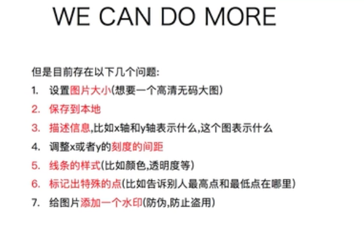

设置图片大小

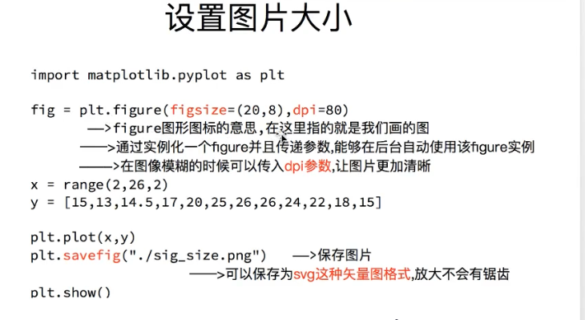

fig = plt.figure(figsize = (20,8),dpi = 80)  
figsize 元组  
图片的保存要在绘图ploy命令之后，这样才能得到对应的图片  
plt.savefig("path/filename.png")

### 调整图片的刻度值

plot.xticks(range(2,25)) 调整xticks()中的数组以改变坐标轴密度  
不显示就不传值

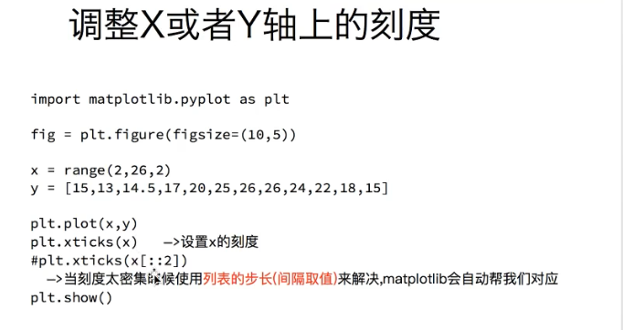

格式化x轴坐标及显示

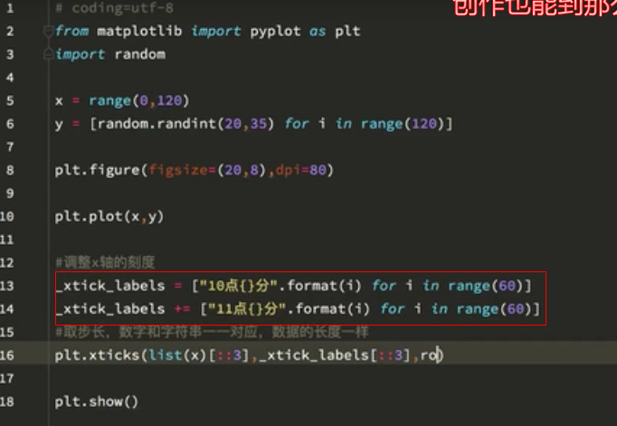

```python
print(["10点{}分".format(i) for i in range(60)])
# 定义元组
```

[output not shown]

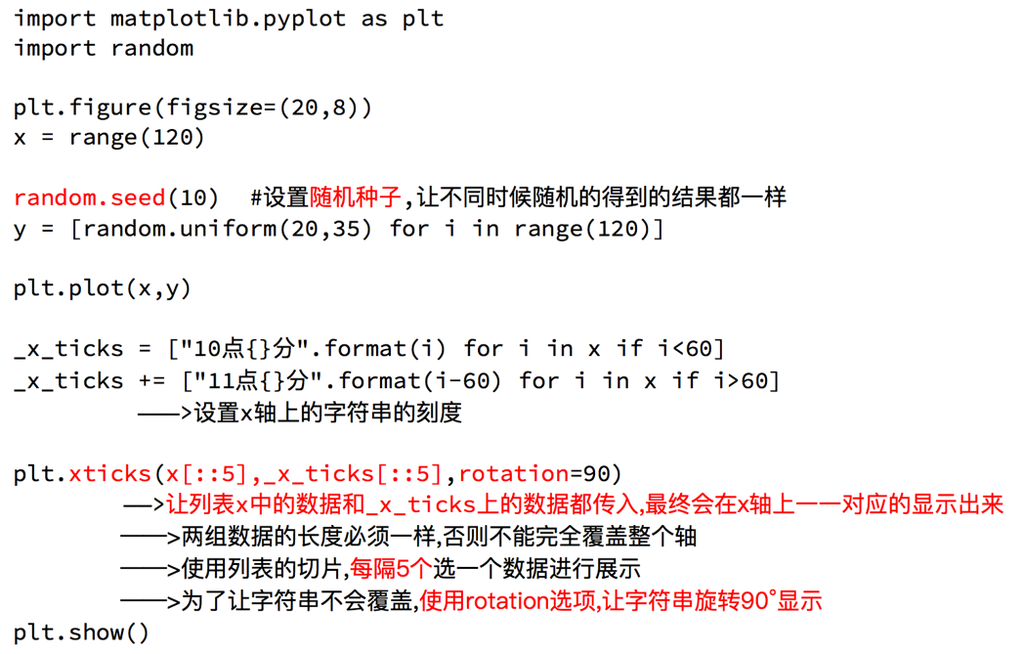

##### 2020年2月4日22:34:15

# 数据分析基础 02

### 1.matplotlib 设置中文字体

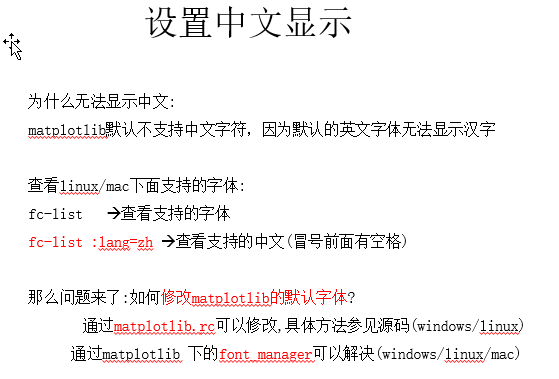

先查看系统支持的中文字体

常用的Linux 命令 TOP 20之一 fc-list 查看系统支持的字体

使用matplotlib.rc 方法修改  
查看源码的方式  
**font相当于直接引用列表中的参数

或者通过 font manager类来修改

14:05

# 2020年2月8日15:13:18

解决中文不显示的问题 P6 11.05  
看源码 修改Demo  
设置字体的一种绝对有效的方法

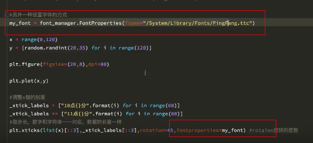

P6 End  
P7 Start

## 添加Label标签

### 通过Label标签给图表添加备注

plt.xlabel("text") → 添加X轴标签 plt.ylabel("text") → 添加Y轴标签 plt.title("title") → 添加图表标题

## 图表绘制练习

P8

## anaconda的安装

### 安装包的获取

环境的配置&conda命令使用  
模块的应用及配置

sh脚本里面切换python环境  
前面添加 source activate python3

### 完成示例

Plot绘图  
调用字体  
绘制label

## 绘制网格线

plt.grid()  
以坐标轴作为网格

### 网格的参数

alpha = 0.4 range 0~1 参数含义为透明度

## 绘制双折线图

两条折线  
调用两次plot方法  
Plot(x,y,label = "tuli1") plot(x,z,label = "tuli2")  
多个参数的标记  
在绘制的同时加Label标签

plt.legend() 增加图例 增加字体 添加**Prop=My_font**参数

```
legend  英[ˈledʒənd]
美[ˈledʒənd]
n.  传说; 传奇故事; (尤指某领域中的) 传奇人物; (地图或书中图表的) 图例，说明，解释;
[例句]The play was based on Irish legend.
这部戏取材于爱尔兰传说。
[其他]    复数：legends
```

# 2020年2月9日16:07:30

# 2020年2月9日16:11:32

legend()参数的使用  
通过查看源码确定其位置  
查看源码可以快速解决问题  
查看源码定义其图例的位置 legend(...,loc = "upper left")

### 定义双折线图的颜色

### 定义上折线图的线条样式

linestyle  
可以定义在折线图，也可以定义网格线（的样式）

##### PPT Page 31

可以利用颜色的十六进制代码来定义（具体代码可以百度）

#### 在图表中添加文本注释 （备注内容）

#### 在图表中添加自定义水印内容

## 总结

##### PPT page 34

matplotlib的其他功能 → 其官方文档 去官网查看对应的图形，点击即可获取到对应的源码  
官方demo

## 常见图形的使用范围及功能

##### PPT Page 36

2020年2月9日17:26:26

直方图和条形图用于连续型&离散型数据的统计  
散点图用于展示离群点（异常值）

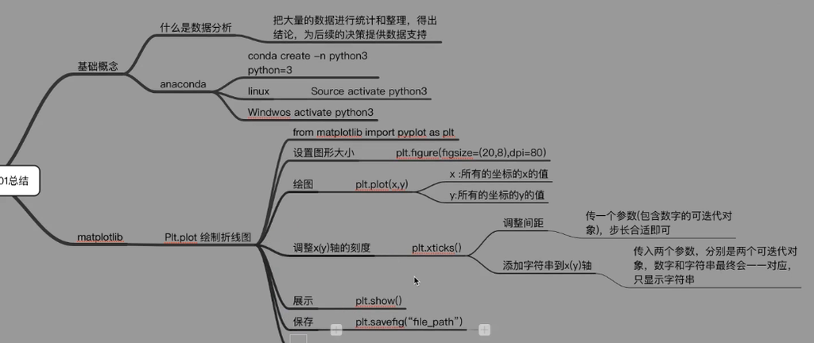

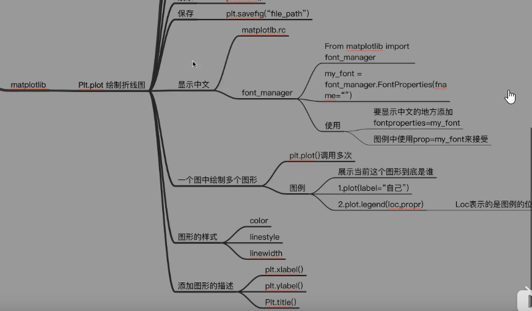

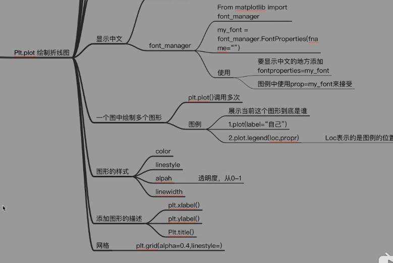

### Video p9-01 绘制散点图

plt.scatter(x,y)

绘制并调整散点图  
设置图形格式等参数  
x[::3] 取步长

### 散点图的更多应用场景

```
最小二乘法 获取拟合直线
```

### 绘制条形图

plt.bar() 绘制条形图的方法  
坐标轴显示不完整  
bar(...,width = 0.3)  
控制条形图的宽度

### 绘制横着的条形图

2020年2月9日21:34:08 利用Python进行可视化的处理和操作  
barh(...,**height = 0.3**)